# IODS course project

Veera Nenonen

### This is a *very* short description about this course

Introduction to Open data science is about using **open** research tools and **open** data. The tools used in this course are for example R, RStudio, RMarkdown and GitHub. The target group of this course is the doctoral students - though it is useful for bacherol and master students too.

[Here](https://github.com/veeranen/IODS-project) is the link for my GitHub repository!

## Week 2: Regression and model validation

In this report we will explore and analyze a dataset that is wrangled from a larger dataset. The data contains information about the students of the course called *Introduction to social statistics*. The original data can be found from [here](http://www.helsinki.fi/~kvehkala/JYTmooc/JYTOPKYS3-data.txt) and explanations of the variables from [here](http://www.helsinki.fi/~kvehkala/JYTmooc/JYTOPKYS3-meta.txt). Some of the variables are adjusted sum variables from the original dataset. The data that is used in this report can also be found from [here](http://s3.amazonaws.com/assets.datacamp.com/production/course_2218/datasets/learning2014.txt) if needed.

First, we will take a good look at the data: structure, variables, observations, the values etc. After we have enough knowledge of the data we can start analyzing. In the analysis part we will use the regression model and fit it to the data. We are also going to use summaries and graphics for describing and visualizing the data.

### Reading and exploring the data

I have already preprocessed the data and saved it in my IODS project file. The data is saved as a CSV file so we’ll read the data with `read.csv()` command. The read data is named as `learn`.

Before any analysis we need to know what the data is like. That is why we’ll use few useful commands which will desribe the data to us so that we don’t have to try to read all the values separately. `dim()` tells us the number of observations and variables of the data. With `str()` we can see the structure of the data. It will show us how many observations and variables the dataset has and what are the datatypes of the variables. It also shows 10 first obseravtions of the dataset. The `summary()` is used to summarize the data - it will tell us the statistics of each variable so we can get a hint how the data is distributed.

```r
dim(learn)
```

```
## [1] 166   7
```

```r
str(learn)
```

```
## 'data.frame':    166 obs. of  7 variables:
##  $ gender      : Factor w/ 2 levels "F","M": 1 2 1 2 2 1 2 1 2 1 ...
##  $ Age         : int  53 55 49 53 49 38 50 37 37 42 ...
##  $ Attitude_adj: num  3.7 3.1 2.5 3.5 3.7 3.8 3.5 2.9 3.8 2.1 ...
##  $ deep_adj    : num  3.58 2.92 3.5 3.5 3.67 ...
##  $ stra_adj    : num  3.38 2.75 3.62 3.12 3.62 ...
##  $ surf_adj    : num  2.58 3.17 2.25 2.25 2.83 ...
##  $ Points      : int  25 12 24 10 22 21 21 31 24 26 ...
```

```r
summary(learn)
```

```
##  gender       Age         Attitude_adj      deep_adj        stra_adj
##  F:110   Min.   :17.00   Min.   :1.400   Min.   :1.583   Min.   :1.250
##  M: 56   1st Qu.:21.00   1st Qu.:2.600   1st Qu.:3.333   1st Qu.:2.625
##          Median :22.00   Median :3.200   Median :3.667   Median :3.188
##          Mean   :25.51   Mean   :3.143   Mean   :3.680   Mean   :3.121
##          3rd Qu.:27.00   3rd Qu.:3.700   3rd Qu.:4.083   3rd Qu.:3.625
##          Max.   :55.00   Max.   :5.000   Max.   :4.917   Max.   :5.000
##     surf_adj         Points
##  Min.   :1.583   Min.   : 7.00
##  1st Qu.:2.417   1st Qu.:19.00
##  Median :2.833   Median :23.00
##  Mean   :2.787   Mean   :22.72
##  3rd Qu.:3.167   3rd Qu.:27.75
##  Max.   :4.333   Max.   :33.00
```

Our dataset has seven variables called `gender`, `Age`, `Attitude`, `deep_adj`, `stra_adj`, `surf_adj` and `Points` (“adj” means that the original variable is adjusted to fit in a certain scale). The number of observations is 166. The summary shows that the variables `Attitude`, `deep`, `stra` and `surf` are on a scale 1 to 5, the age of the observated people is from 17 to 55 and that their points differ between seven and 33. Summary also calculates median and mean of each variable, except gender which is not a quantitative variable. We can see that there are almost twice as much females than males in the dataset. The description link of the variables (link is given in the first chapter of this report) says that the variable Attitude measures the attitude of the respondents towards statistics. Deep, Strategic and Surface are sum variables calculated from multiple variables and they measure how much the students belong in a certain learning approach. The higher the value, the more a student seems to use the method. Means and medians are all close to number 3 in each approach but we can see that deep has highest mean and median while surface has the lowest ones.

Now we are more familiar with the data so we can move on with the visualization to get more information about the distributions and relationships between the variables.

### Visualization

First it would be good to find out how the observations are distributed within each variable. One way to achieve this is to make some graphs from the variables. All the variables except gender are numerical and somewhat continuous so that is why a histogram would be a worthy option. The histograms look like this:

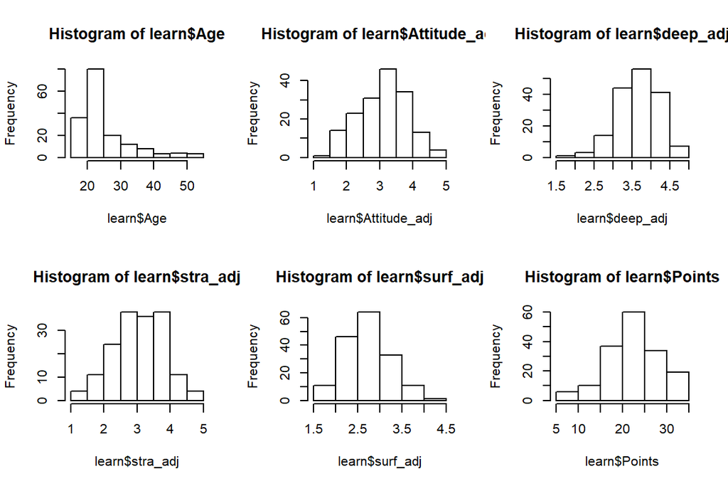

```r
par(mfrow = c(2,3))
hist(learn$Age)
hist(learn$Attitude_adj)
hist(learn$deep_adj)
hist(learn$stra_adj)
hist(learn$surf_adj)
hist(learn$Points)
```

We can clearly see that most of the respondents are 20-25 years old. Almost half of the observations belong in that group. Rest of the groups are much smaller, especially age of 40 and older. Other variables appear to be almost normally distributed - most of the values are located in the middle of the range and the bars get shorter when moving closer to the minimum and maximum points. The summary statistics that were calculated earlier make more sense now that they are visualized in a graph.

We would like to know more about the relationships between different variables. Are some of the variables correlaing or is there a certain trend going on? First would be interesting to find out if different learning approaches have anything to do with the points and vice versa. We’ll use a scatter plot for this purpose. Let’s make simple plots for the variables `deep`, `stra` and `surf` with `Points`:

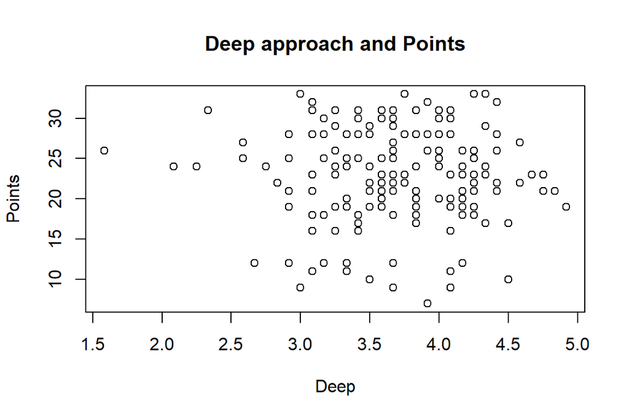

```r
plot(learn$deep_adj, learn$Points, main = "Deep approach and Points",
    xlab="Deep", ylab = "Points")
```

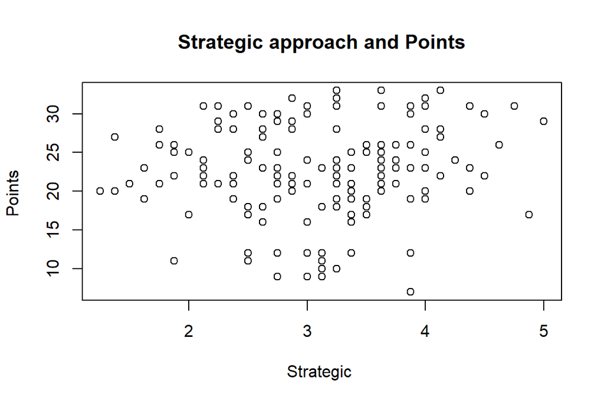

```r
plot(learn$stra_adj, learn$Points, main = "Strategic approach and Points",
    xlab="Strategic ", ylab = "Points ")
```

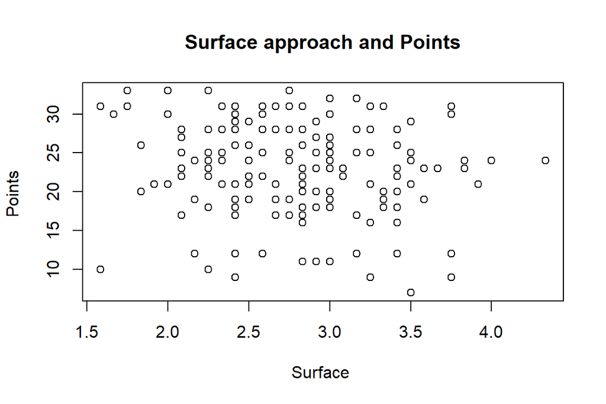

```r
plot(learn$surf_adj, learn$Points, main = "Surface approach and Points",
    xlab="Surface ", ylab = "Points ")
```

The data points seem to scatter all aroud the range and there is no visible correlation in any of the plots. The data mass is located a little bit differently within each learning approach but none of them has anything to do with the points earned. We could try the same with the attitude variable and points to find out if they have anything to do with each other.

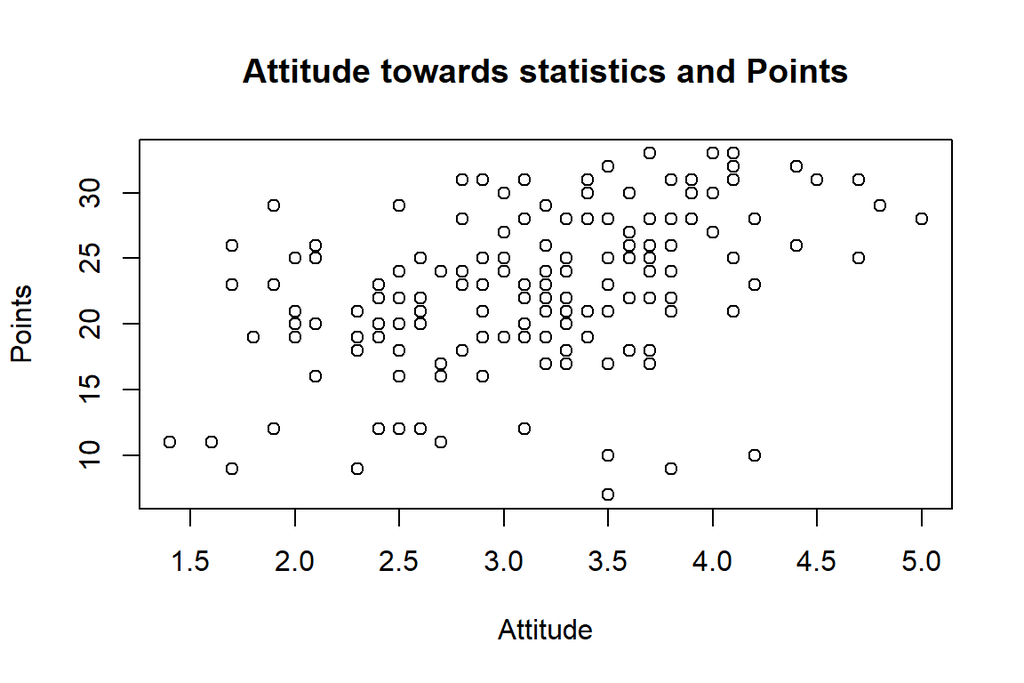

```r
plot(learn$Attitude_adj, learn$Points, main = "Attitude towards statistics and Points",
    xlab="Attitude", ylab = "Points")
```

This looks more interesting. We can see that high attitude scores locate more higher in the y axis. This implies that those who have said to have better attitude towards statistics have higher scores. I’d like to know if there are any differnce between different groups. Let’s plot same variables again but this time we’ll mark females and males in different colors. This way we can see if females and males differ in any way. This time we’ll use package `ggplot` that makes a little bit different graphs.

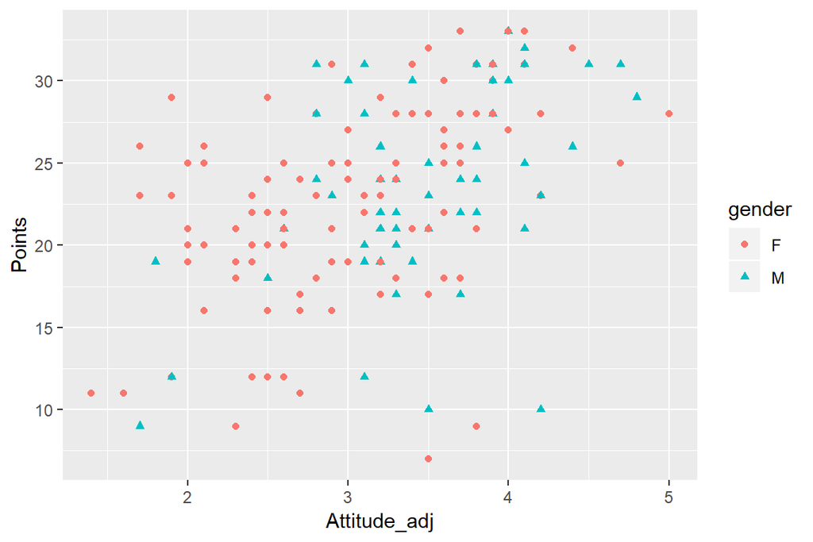

```r
library(ggplot2)
ggplot(learn, aes(x = Attitude_adj , y = Points, color = gender, shape = gender)) +
  geom_point()
```

It is a bit difficult to compare males and females since there are twice more females. However, it seems that there is no significant difference between females and males so the attitude score and exam points distribute pretty same in both genders.

Next we can do some deeper analysis to the data and actually do some model fitting!

### Regression and model fitting

We are supposed to choose three explanatory variables for regression model. Because we already examined the correlation between `attitude` and `Points` and actually found something interesting it would be a good choice to take it as a one variable. Let’s also choose age because we don’t know yet how it would impact the model. Last one shall be `deep` because I’d like to see if one learning approach would actually make the model much different.

The simple linear regression is quite straight-forward to do with R because it actually doesn’t need much code. Let’s fit the model and take a look at the summary and some graphs:

```r
model <- lm(Points ~ Attitude_adj + Age + deep_adj, data = learn)
summary(model)
```

```
##
## Call:
## lm(formula = Points ~ Attitude_adj + Age + deep_adj, data = learn)
##
## Residuals:
##     Min      1Q  Median      3Q     Max
## -17.206  -3.430   0.204   3.979  10.950
##
## Coefficients:
##              Estimate Std. Error t value Pr(>|t|)
## (Intercept)  15.60773    3.38966   4.605 8.32e-06 ***
## Attitude_adj  3.59413    0.56959   6.310 2.56e-09 ***
## Age          -0.07716    0.05322  -1.450    0.149
## deep_adj     -0.60275    0.75031  -0.803    0.423
## ---
## Signif. codes:  0 '***' 0.001 '**' 0.01 '*' 0.05 '.' 0.1 ' ' 1
##
## Residual standard error: 5.307 on 162 degrees of freedom
## Multiple R-squared:  0.2043, Adjusted R-squared:  0.1896
## F-statistic: 13.87 on 3 and 162 DF,  p-value: 4.305e-08
```

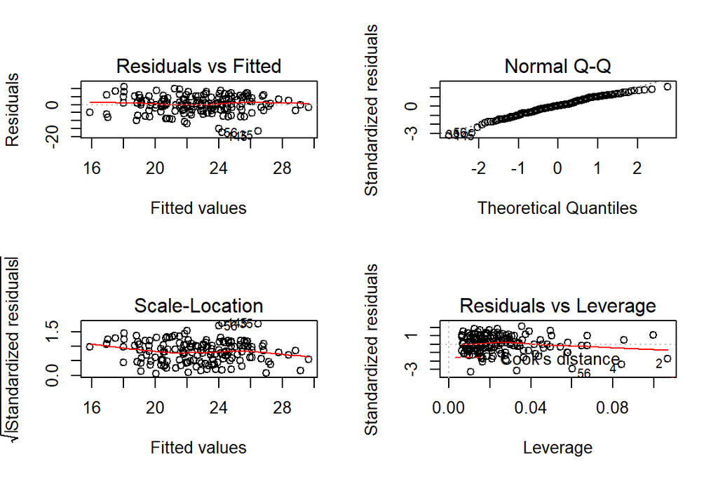

```r
par(mfrow = c(2,2))
plot(model)
```

First we’ll examine the summary. We can see that residuals did not distribute very symmetrically. It means that some of the observed values differed a lot from the predicted model. The estimate for the value of the alpha is 15.61 and for the beta values are 3.59 (Attitude), -0.08 (Age) and -0.60 (Deep). This tells us that an average student in our dataset would get approximately 15.61 points and one point increase on attitude would increase the exam points approximately by 3.6. If the age would increase by one year the number of points would actually decrease but the impact is actually very low. One point increase in deep approach would also decrease the point but in this case the amount is really small. If we’ll look at the p-values (`P(>|t|)`) we can see that the values are pretty high on age and deep ones (0.149 and 0.423) which means that we cannot really conclude that there is a significant relationship between points and those two variables. But if we look at the p-value of the attitude variable, it is actually really small which implies that the relationship between points and attitude is significant. So this tells us that the enthusiasm towards statistics and higher points have something to do with each other. There are also multiple R-squared and adjusted R-squared values that describes how well the model fits the data. The closer the value is to, 1 the better fit and the better the explanatory variables actually explain the variable we are trying to explain. In this case the value is only ~0.2 which means pretty poor fit. We would need other and better explaining variables to get better fit. The adjusted R-squared value adjusts the model for the number of variables since the multiple R-squared always increases when more variables are added. The graphs visualize residuals and model goodness. **Residuals vs Fitted** one shows if there are any other possible relationships between predictor and outcome variables that are not linear. In our case everything seems to be fine since the line is a nice horizontal line. **The normal QQ** plot tells us how the residuals are distributed. They seem to follow pretty straight line even though there are few values that are pretty far from the line. It means that the residuas are approximately normally distributed which is what we are hoping. **Residuals vs leverage** can tell if there are outliers or extreme values that impact too much on the model. If that would be the case, the Cook’s distance would get closer to the red line in the middle and there would be values outside the line compared to the graph we are having here. We don’t seem to have any extreme values that should be left out.

Let’s try the model again but without the variables that do not actually have significant relationship with the exam points. This means that we’ll only use variable `Attitude_adj`.

```r
second_model <- lm(Points ~ Attitude_adj, data = learn)
summary(second_model)
```

```
##
## Call:
## lm(formula = Points ~ Attitude_adj, data = learn)
##
## Residuals:
##      Min       1Q   Median       3Q      Max
## -16.9763  -3.2119   0.4339   4.1534  10.6645
##
## Coefficients:
##              Estimate Std. Error t value Pr(>|t|)
## (Intercept)   11.6372     1.8303   6.358 1.95e-09 ***
## Attitude_adj   3.5255     0.5674   6.214 4.12e-09 ***
## ---
## Signif. codes:  0 '***' 0.001 '**' 0.01 '*' 0.05 '.' 0.1 ' ' 1
##
## Residual standard error: 5.32 on 164 degrees of freedom
## Multiple R-squared:  0.1906, Adjusted R-squared:  0.1856
## F-statistic: 38.61 on 1 and 164 DF,  p-value: 4.119e-09
```

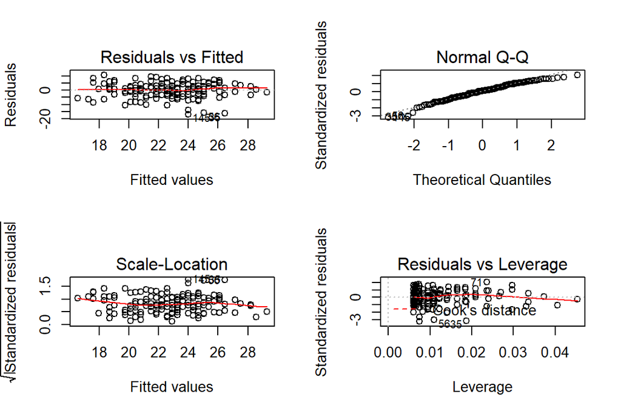

```r
par(mfrow = c(2,2))
plot(second_model)
```

The summary statistics changed a little bit but the significance of the relationship between the variables did not change. The alpha value decreased little bit and the p value increased but the significance is still the same. Also the R-squared value decreased which means that the attitude value does not on its own explain the exam points very well.

All in all, we noticed some correlations between variables but they do not explain each other very well so we would need more tests to actually explain the exam points.

## Week 3: Logistic regression

### The data

In this report we will analyze a dataset from UCI Machine Learning Repository. The data is called [Student Performance Dataset](https://archive.ics.uci.edu/ml/datasets/Student+Performance) and it actually consists two different datasets. Both datasets are collected from students of Portuguese schools. The first one is from students of Mathematics and the other is from Portuguese students. The data has been preprocessed earlier so now the dataset for the analysis is a single dataframe that is merged from two sets. The data has some basic information about the students - for example age, sex, parents’ education and job, and relationship status - but the main focus is in the variables about alcohol consumption. Let’s take a closer look at the data.

First we’ll take a look at the variables:

```r
alc <- read.csv("~/IODS-project/data/alc.csv")

dim(alc)
```

```
## [1] 382  35
```

```r
colnames(alc)
```

```
##  [1] "school"     "sex"        "age"        "address"    "famsize"
##  [6] "Pstatus"    "Medu"       "Fedu"       "Mjob"       "Fjob"
## [11] "reason"     "nursery"    "internet"   "guardian"   "traveltime"
## [16] "studytime"  "failures"   "schoolsup"  "famsup"     "paid"
## [21] "activities" "higher"     "romantic"   "famrel"     "freetime"
## [26] "goout"      "Dalc"       "Walc"       "health"     "absences"
## [31] "G1"         "G2"         "G3"         "alc_use"    "high_use"
```

The data called `alc` has 35 variables and 382 observations. The dataset does not have student IDs or any other unambiguous identifiers. The respondents are identified by a combinations of 13 different variables that are actually the 13 first columns in the dataframe. There are four variables especially about alcohol consumptions: `Dalc`, `Walc`, `alc_use` and `high_use`. First one tells the amount of alcohol consumption in workdays and the second one in weekends. Third one is the average of these two and the fourth one is a boolean variable that tells if the consumption is high or not (high use means that the average consumption is greater than two). The meanings of other variables can be seen from the UCI Machine Learning Repository’s page that is linked in the beginning of this report.

### Hypotheses and distribution exploring

We want to know if there are any relationships between different variables and alcohol consumption. The variables I’m interested in are weekly studytime (`studytime`), quality of family realtionships (`famrel`), current health status (`health`) and number of absences (`absences`). No we can state the hypotheses:

- **$H_0$:** Weekly studytime and alcohol consumption do not have a significant relationship.
- **$H_1$:** Weekly studytime and alcohol consumption do have a significant relationship. My wild guess is that if there was a relationship, the higher the studytime, the lower alcohol consumption.
- **$H_0$:** Quality of family relationships and alcohol consumption do not have a significant relationship.
- **$H_1$:** Quality of family relationships and alcohol consumption do have a significant relationship. Without other information I would think that difficult family relationships indicate higher alcohol consumption.
- **$H_0$:** Current health status and alcohol consumption do not have a significant relationship.
- **$H_1$:** Current health status and alcohol consumption do have a significant relationship. It is already known that high alcohol consmuption increases health risks but there are other factors that impact on health too.
- **$H_0$:** Number of absences and alcohol consumption do not have a significant relationship.
- **$H_1$:** Number of absences and alcohol consumption do have a significant relationship. I think that if there was a relationship between these variables, probably higher amount of absences would go together with higher alcohol consumption.

The qualities of the relationships in the H1s are only my assumings before we know anything else. Next we will move on to visualizing these variables. Let’s start by making barcharts or histograms of each variable to see how the values distribute.

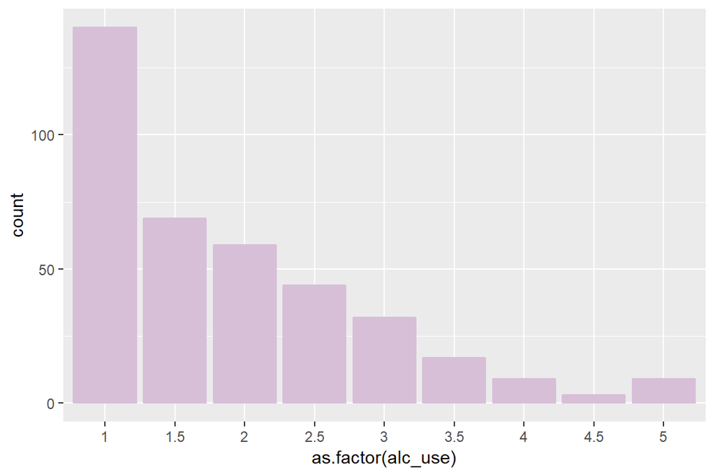

```r
ggplot(alc, aes(x = as.factor(alc_use))) + geom_bar(col = "thistle", fill = "thistle")
```

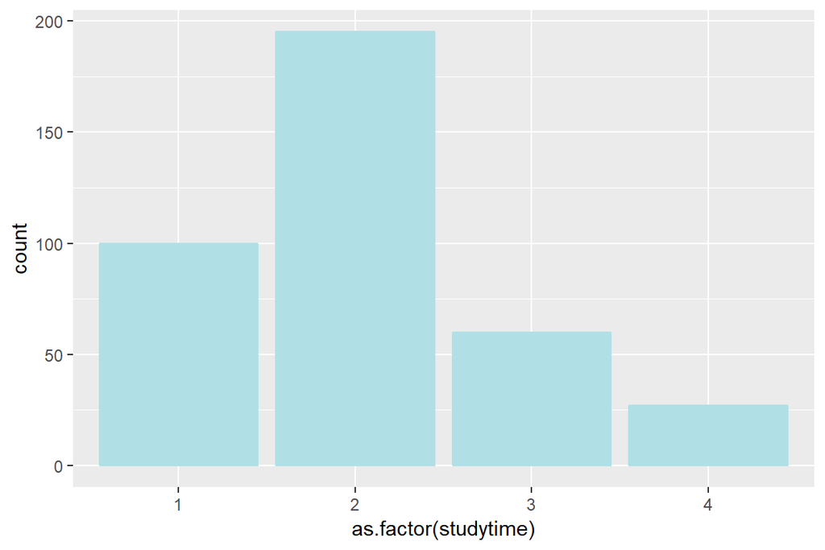

```r
ggplot(alc, aes(x = as.factor(studytime))) + geom_bar(col = "powderblue", fill = "powderblue")
```

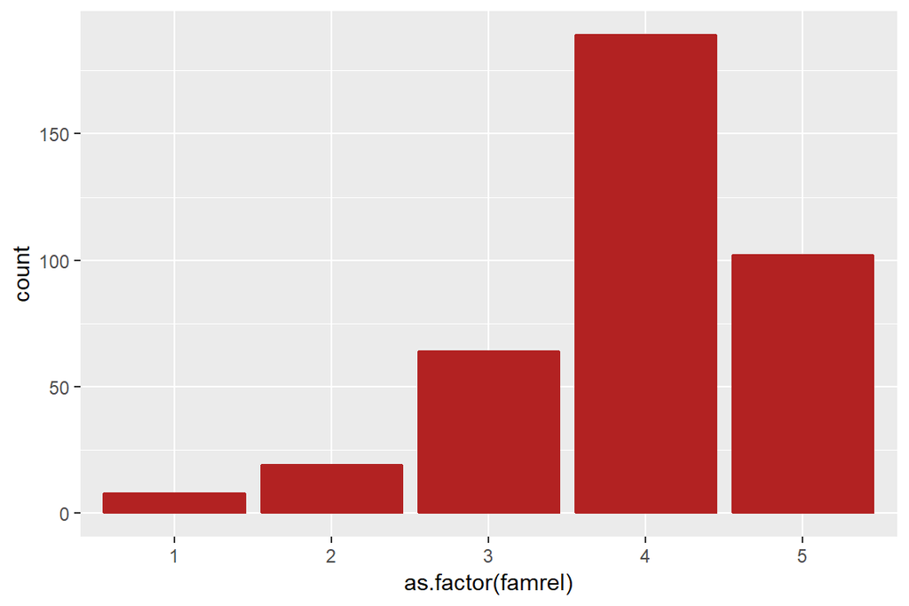

```r
ggplot(alc, aes(x = as.factor(famrel))) + geom_bar(col = "firebrick", fill = "firebrick")
```

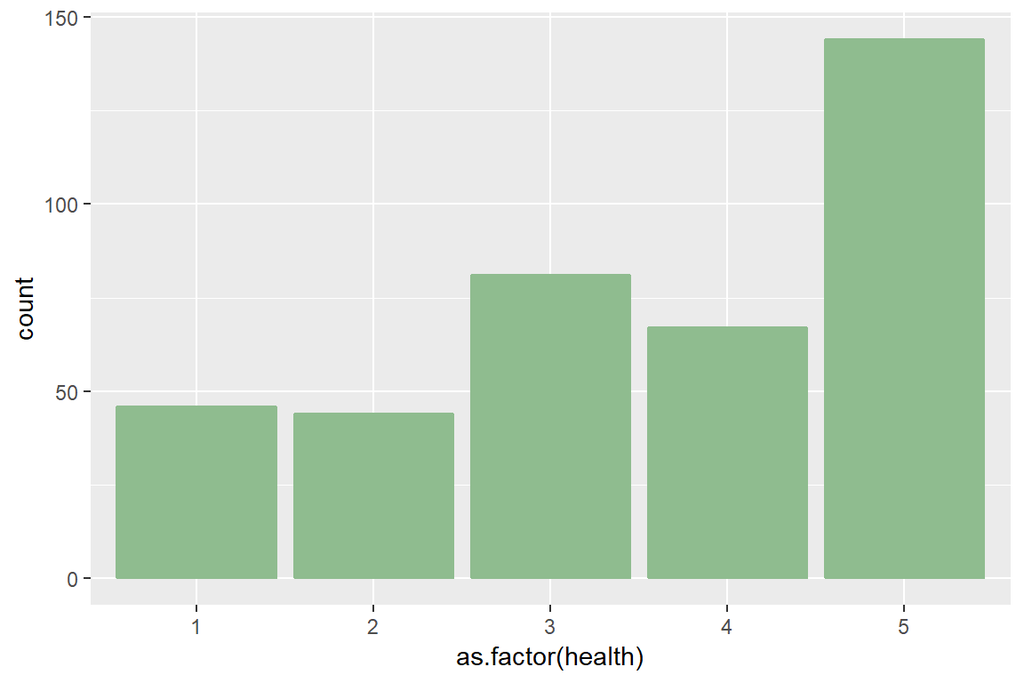

```r
ggplot(alc, aes(x = as.factor(health))) + geom_bar(col = "darkseagreen", fill = "darkseagreen")
```

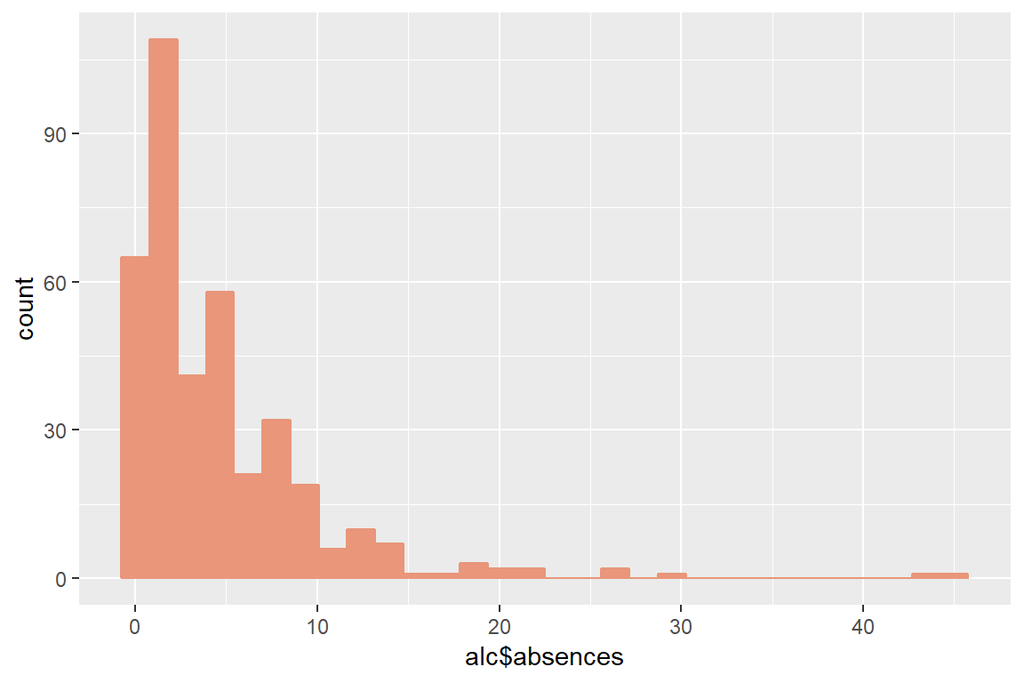

```r
ggplot(data = alc, aes(alc$absences)) + geom_histogram(col = "darksalmon", fill = "darksalmon")
```

We can see that most of the students’ alcohol consumption is very low or low. Minority of the students belong in the high consumption group. If we take a look at the second chart, clearly the highest bar is the one with value two which means studying 2 to 5 hours in a week. Other groups are much smaller, and the number of students that study more than 10 hours a week is far less than 50. Also mot of the students have a good relationships to their family, are in a good health and have 10 or less absences.

Now we can take a look at the variables together. Let’s start with weekly studying time and alcohol usage. A boxplot would be a good choice for this purpose since both of the values are not continuous and in a narrow range.

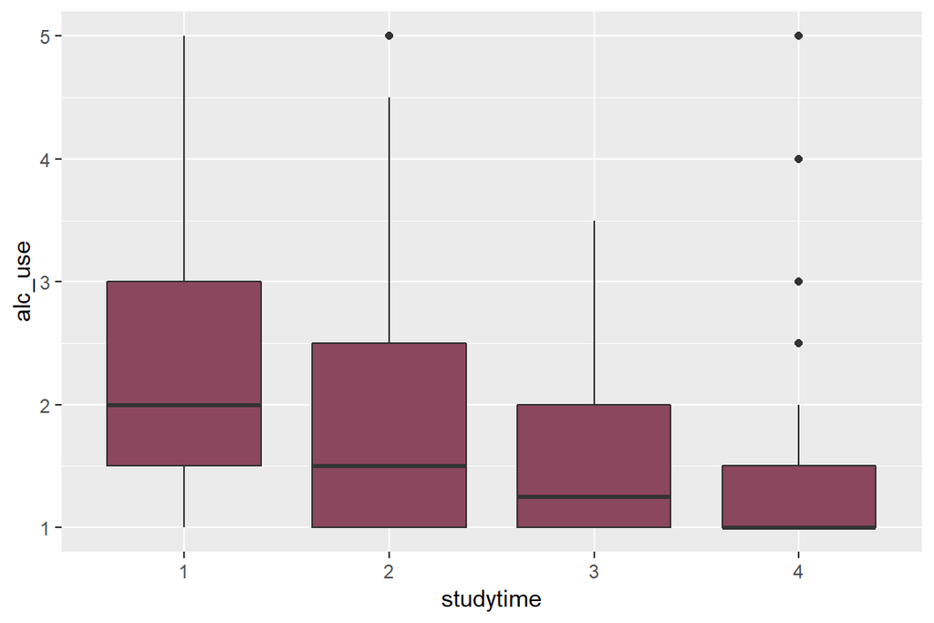

```r
ggplot(alc, aes(x = as.factor(studytime), y = alc_use)) +
    geom_boxplot(fill = "palevioletred4") +
    xlab("studytime")
```

There seems to be some kind of pattern between these variables. The ones that don’t spend much time on studying seem to have higher alcohol consumption compared to the ones with longer studying times. There seems to be few outliers on the right side of the x axis though. The boxes and the ranges clearly locate lower when going closer to right side of the plot. None of the groups don’t have significantly high average consumption but it seems that there is a correlation between study time and alcohol consumption.

Next we’ll do the same with family relationships:

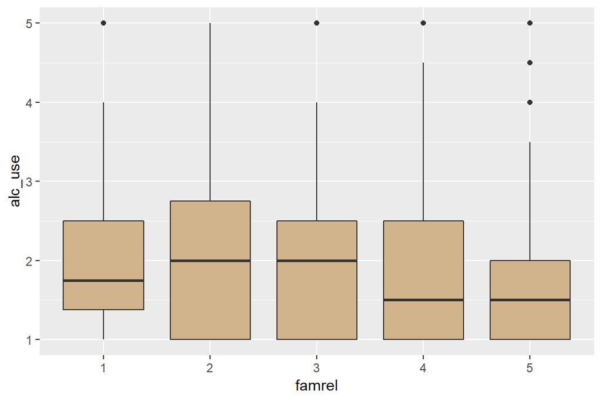

```r
ggplot(alc, aes(x = as.factor(famrel), y = alc_use)) +
    geom_boxplot(fill = "tan") +
    xlab("famrel")
```

This time differences between groups don’t seem as clear as in the previous one. The ranges are not the same width and the means are not completely same but they are quite close to each other. Most of the values clearly are located below value 3 in alcohol consumption. The means of the groups that have better relationships to their families are slightly lower And the width is the narrowest in the the group 5 though there are also many outliers.

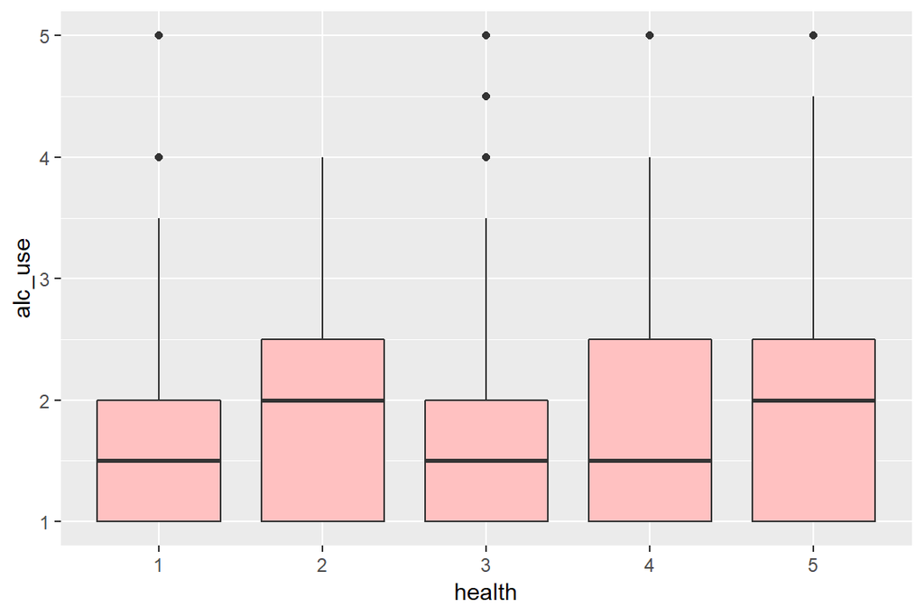

```r
ggplot(alc, aes(x = as.factor(health), y = alc_use)) +
    geom_boxplot(fill = "rosybrown1") +
    xlab("health")
```

This is interesting. I was quite sure that those who say having bad health would be the ones that use more alcohol but it seems not be the case. The lowest alcohol consumption seems to be in groups 1 and 3 and they are ones with bad or “not-bad-not-good”" health. The highest means are in groups 2 and 5 which is unexpected. Overall it looks like I was pretty wrong about these two variables.

Last we have the absences. This is a bit tricky variable because we actually have over 40 different classes. I am going to do a boxplot too but before that I will divide the absence variable into groups. The variable is not distributed evenly at all so the ranges of the groups are not going to be completely same range. The groups will be:  
**1** - No absences at all or 1 absence  
**2** - 2 to 5 absences  
**3** - 6 to 10 absences  
**4** - 10 to 15 absences  
**5** - More than 15 absences

The possible maximum values of absences is 93 but in the data the maximum is 45.

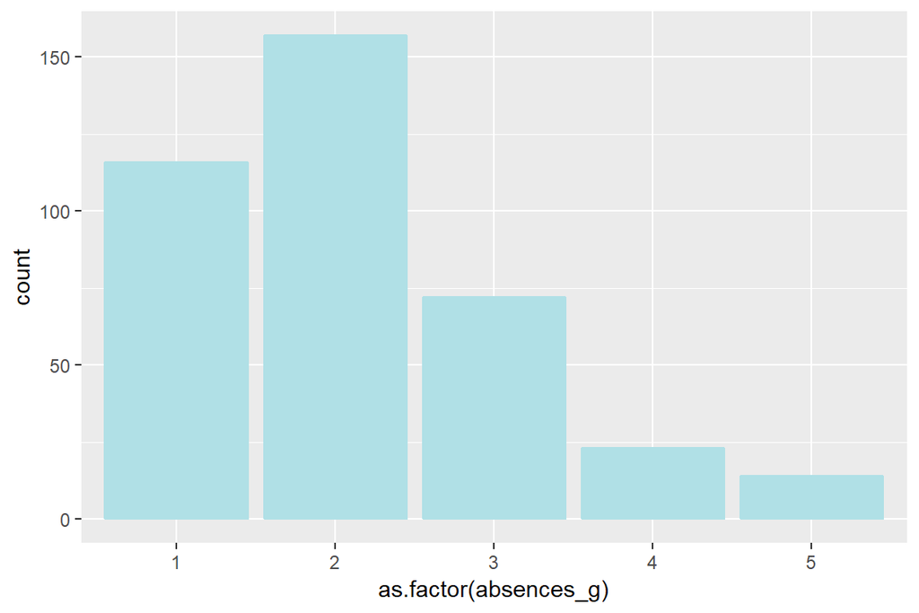

```r
attach(alc)
alc$absences_g[absences <= 1] <- 1
alc$absences_g[absences > 1 & absences <= 5] <- 2
alc$absences_g[absences > 5 & absences <= 10] <- 3
alc$absences_g[absences > 10 & absences <= 15] <- 4
alc$absences_g[absences > 15] <- 5
detach(alc)

ggplot(alc, aes(x = as.factor(absences_g))) + geom_bar(col = "powderblue", fill = "powderblue")
```

Now that we have our new categorized variable we can make the boxplot.

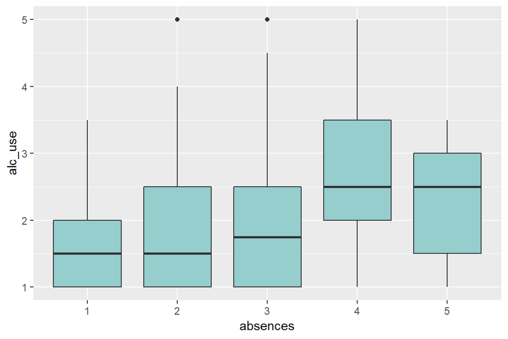

```r
ggplot(alc, aes(x = as.factor(absences_g), y = alc_use)) +
    geom_boxplot(fill = "paleturquoise3") +
    xlab("absences")
```

Here we can also see some differences between different amounts of absences. There are clearly higher alcohol consumption in the groups that have high number of absences. The first and third quartiles in the group 4 are completely above the ones of the group one which indicates that there is clear difference. Interesting is that the group 5 is located lower than 4 even though the means seem to be same.

The plots indicate that in some of the cases there could happen a rejection of the null hypothesis, especially with the study time variable. But we don’t want to celebrate yet since there arestill lots of things to test.

Last we will make cross-tabulations to each four variables with the value `high_use` as a summary and to see how they act together. We’ll use the `gmodels` package for the tabulation.

```r
library(gmodels)
CrossTable(alc$high_use, alc$studytime)
```

```
##
##
##    Cell Contents
## |-------------------------|
## |                       N |
## | Chi-square contribution |
## |           N / Row Total |
## |           N / Col Total |
## |         N / Table Total |
## |-------------------------|
##
##
## Total Observations in Table:  382
##
##
##              | alc$studytime
## alc$high_use |         1 |         2 |         3 |         4 | Row Total |
## -------------|-----------|-----------|-----------|-----------|-----------|
##        FALSE |        58 |       135 |        52 |        23 |       268 |
##              |     2.107 |     0.024 |     2.331 |     0.869 |           |
##              |     0.216 |     0.504 |     0.194 |     0.086 |     0.702 |
##              |     0.580 |     0.692 |     0.867 |     0.852 |           |
##              |     0.152 |     0.353 |     0.136 |     0.060 |           |
## -------------|-----------|-----------|-----------|-----------|-----------|
##         TRUE |        42 |        60 |         8 |         4 |       114 |
##              |     4.952 |     0.056 |     5.480 |     2.043 |           |
##              |     0.368 |     0.526 |     0.070 |     0.035 |     0.298 |
##              |     0.420 |     0.308 |     0.133 |     0.148 |           |
##              |     0.110 |     0.157 |     0.021 |     0.010 |           |
## -------------|-----------|-----------|-----------|-----------|-----------|
## Column Total |       100 |       195 |        60 |        27 |       382 |
##              |     0.262 |     0.510 |     0.157 |     0.071 |           |
## -------------|-----------|-----------|-----------|-----------|-----------|
##
##
```

```r
CrossTable(alc$high_use, alc$famrel)
```

```
##
##
##    Cell Contents
## |-------------------------|
## |                       N |
## | Chi-square contribution |
## |           N / Row Total |
## |           N / Col Total |
## |         N / Table Total |
## |-------------------------|
##
##
## Total Observations in Table:  382
##
##
##              | alc$famrel
## alc$high_use |         1 |         2 |         3 |         4 |         5 | Row Total |
## -------------|-----------|-----------|-----------|-----------|-----------|-----------|
##        FALSE |         6 |        10 |        39 |       135 |        78 |       268 |
##              |     0.027 |     0.832 |     0.775 |     0.044 |     0.580 |           |
##              |     0.022 |     0.037 |     0.146 |     0.504 |     0.291 |     0.702 |
##              |     0.750 |     0.526 |     0.609 |     0.714 |     0.765 |           |
##              |     0.016 |     0.026 |     0.102 |     0.353 |     0.204 |           |
## -------------|-----------|-----------|-----------|-----------|-----------|-----------|
##         TRUE |         2 |         9 |        25 |        54 |        24 |       114 |
##              |     0.063 |     1.955 |     1.823 |     0.102 |     1.362 |           |
##              |     0.018 |     0.079 |     0.219 |     0.474 |     0.211 |     0.298 |
##              |     0.250 |     0.474 |     0.391 |     0.286 |     0.235 |           |
##              |     0.005 |     0.024 |     0.065 |     0.141 |     0.063 |           |
## -------------|-----------|-----------|-----------|-----------|-----------|-----------|
## Column Total |         8 |        19 |        64 |       189 |       102 |       382 |
##              |     0.021 |     0.050 |     0.168 |     0.495 |     0.267 |           |
## -------------|-----------|-----------|-----------|-----------|-----------|-----------|
##
##
```

```r
CrossTable(alc$high_use, alc$health)
```

```
##
##
##    Cell Contents
## |-------------------------|
## |                       N |
## | Chi-square contribution |
## |           N / Row Total |
## |           N / Col Total |
## |         N / Table Total |
## |-------------------------|
##
##
## Total Observations in Table:  382
##
##
##              | alc$health
## alc$high_use |         1 |         2 |         3 |         4 |         5 | Row Total |
## -------------|-----------|-----------|-----------|-----------|-----------|-----------|
##        FALSE |        35 |        28 |        62 |        49 |        94 |       268 |
##              |     0.231 |     0.267 |     0.471 |     0.085 |     0.489 |           |
##              |     0.131 |     0.104 |     0.231 |     0.183 |     0.351 |     0.702 |
##              |     0.761 |     0.636 |     0.765 |     0.731 |     0.653 |           |
##              |     0.092 |     0.073 |     0.162 |     0.128 |     0.246 |           |
## -------------|-----------|-----------|-----------|-----------|-----------|-----------|
##         TRUE |        11 |        16 |        19 |        18 |        50 |       114 |
##              |     0.542 |     0.627 |     1.107 |     0.199 |     1.149 |           |
##              |     0.096 |     0.140 |     0.167 |     0.158 |     0.439 |     0.298 |
##              |     0.239 |     0.364 |     0.235 |     0.269 |     0.347 |           |
##              |     0.029 |     0.042 |     0.050 |     0.047 |     0.131 |           |
## -------------|-----------|-----------|-----------|-----------|-----------|-----------|
## Column Total |        46 |        44 |        81 |        67 |       144 |       382 |
##              |     0.120 |     0.115 |     0.212 |     0.175 |     0.377 |           |
## -------------|-----------|-----------|-----------|-----------|-----------|-----------|
##
##
```

```r
CrossTable(alc$high_use, alc$absences_g)
```

```
##
##
##    Cell Contents
## |-------------------------|
## |                       N |
## | Chi-square contribution |
## |           N / Row Total |
## |           N / Col Total |
## |         N / Table Total |
## |-------------------------|
##
##
## Total Observations in Table:  382
##
##
##              | alc$absences_g
## alc$high_use |         1 |         2 |         3 |         4 |         5 | Row Total |
## -------------|-----------|-----------|-----------|-----------|-----------|-----------|
##        FALSE |        90 |       115 |        50 |         8 |         5 |       268 |
##              |     0.913 |     0.214 |     0.005 |     4.102 |     2.367 |           |
##              |     0.336 |     0.429 |     0.187 |     0.030 |     0.019 |     0.702 |
##              |     0.776 |     0.732 |     0.694 |     0.348 |     0.357 |           |
##              |     0.236 |     0.301 |     0.131 |     0.021 |     0.013 |           |
## -------------|-----------|-----------|-----------|-----------|-----------|-----------|
##         TRUE |        26 |        42 |        22 |        15 |         9 |       114 |
##              |     2.145 |     0.503 |     0.012 |     9.644 |     5.565 |           |
##              |     0.228 |     0.368 |     0.193 |     0.132 |     0.079 |     0.298 |
##              |     0.224 |     0.268 |     0.306 |     0.652 |     0.643 |           |
##              |     0.068 |     0.110 |     0.058 |     0.039 |     0.024 |           |
## -------------|-----------|-----------|-----------|-----------|-----------|-----------|
## Column Total |       116 |       157 |        72 |        23 |        14 |       382 |
##              |     0.304 |     0.411 |     0.188 |     0.060 |     0.037 |           |
## -------------|-----------|-----------|-----------|-----------|-----------|-----------|
##
##
```

There are a lot to chew in those tables but we don’t have to look all of the values in them. The only thing that actually catches our attention is that some of the cells have a really small sample size which can be a little bit problematic because they might give a bit biased impression in the plots. However, it doesn’t mean that there isn’t any relationships between these variables and that is what we are going to look closer next.

### Logistic regression

Now we are ready to use the logistic regression to see how well our variables can explain the `high_use` variable which means the high usage of alcohol. Our model is obviously binomial logistic regression model since the variable we re trying to predict is binary (TRUE/FALSE). Let’s test the model:

```r
model <- glm(high_use ~ studytime + famrel + health + absences, data = alc, family = "binomial")
summary(model)
```

```
##
## Call:
## glm(formula = high_use ~ studytime + famrel + health + absences,
##     family = "binomial", data = alc)
##
## Deviance Residuals:
##     Min       1Q   Median       3Q      Max
## -2.2161  -0.8338  -0.6430   1.2012   2.1177
##
## Coefficients:
##             Estimate Std. Error z value Pr(>|z|)
## (Intercept)  0.43506    0.66151   0.658 0.510744
## studytime   -0.52965    0.15593  -3.397 0.000682 ***
## famrel      -0.25091    0.12753  -1.967 0.049136 *
## health       0.09581    0.08591   1.115 0.264722
## absences     0.07810    0.02244   3.481 0.000500 ***
## ---
## Signif. codes:  0 '***' 0.001 '**' 0.01 '*' 0.05 '.' 0.1 ' ' 1
##
## (Dispersion parameter for binomial family taken to be 1)
##
##     Null deviance: 465.68  on 381  degrees of freedom
## Residual deviance: 428.93  on 377  degrees of freedom
## AIC: 438.93
##
## Number of Fisher Scoring iterations: 4
```

If we look at the summary we can see that `studytime` and `famrel` have negative values in coefficients (-0.52 & -0.25). This means that increase in one of these values means decrease in alcohol usage. So according to the model, longer studying times and better family relationships would mean lower alcohol consumption. `health` and `absences` seem to have non-negative values (0.095 & 0.078) so increase in these values would mean also increasing alcohol consumption. But if we look at the p-values (`Pr(>|z|)` column) we can see that all of them except the one with health are less than 0.05 which indicates that studying time, family realtionships and absences have significant relationships with high alcohol usage. Although family relationships variable is *just* under the line. Instead health does not have significnace. This makes sense in some way because usually it is other way around: alcohol consumption is a common factor that is explaining quality of health.

Here are the coefficients as odds ratios and also the confidence intervals:

```r
ratios <- coef(model) %>% exp
cint <- confint(model) %>% exp

cbind(ratios, cint)
```

```
##                ratios     2.5 %    97.5 %
## (Intercept) 1.5450539 0.4203620 5.6768721
## studytime   0.5888086 0.4295746 0.7927483
## famrel      0.7780925 0.6052347 0.9995749
## health      1.1005533 0.9316592 1.3057652
## absences    1.0812331 1.0368667 1.1325258
```

These values mean that the ones with ratio greater than 1 are associated with TRUE value in `high_use`. And in this case they are health and absences like we concluded from the summary. The confidence intervals differ a lot between variables. For example with absences the interval is really narrow compared to the one with intercept. So if we think about the hypotheses we stated earlier, we could reject three of them. And I was not completely wrong when I guessed the quality of the relationships.

### Predicting

Now we can use our model for making predictions! We will use all four variables even though one of them was not very efficient. We are first going to make predictions and calculate the probabilities of the TRUE values. If the probability is greater than 0.5 the value will be TRUE and vice versa. We will produce a table that will show the actual `high_use` values and the predicted ones.

```r
probabilities <- predict(model, type = "response") # predict the probabilites
alc <- mutate(alc, probability = probabilities) # add the probabilities in the 'alc' dataframe
alc <- mutate(alc, prediction = probability > 0.5) # add the predicted values

table(high_use = alc$high_use, prediction = alc$prediction)
```

```
##         prediction
## high_use FALSE TRUE
##    FALSE   253   15
##    TRUE     98   16
```

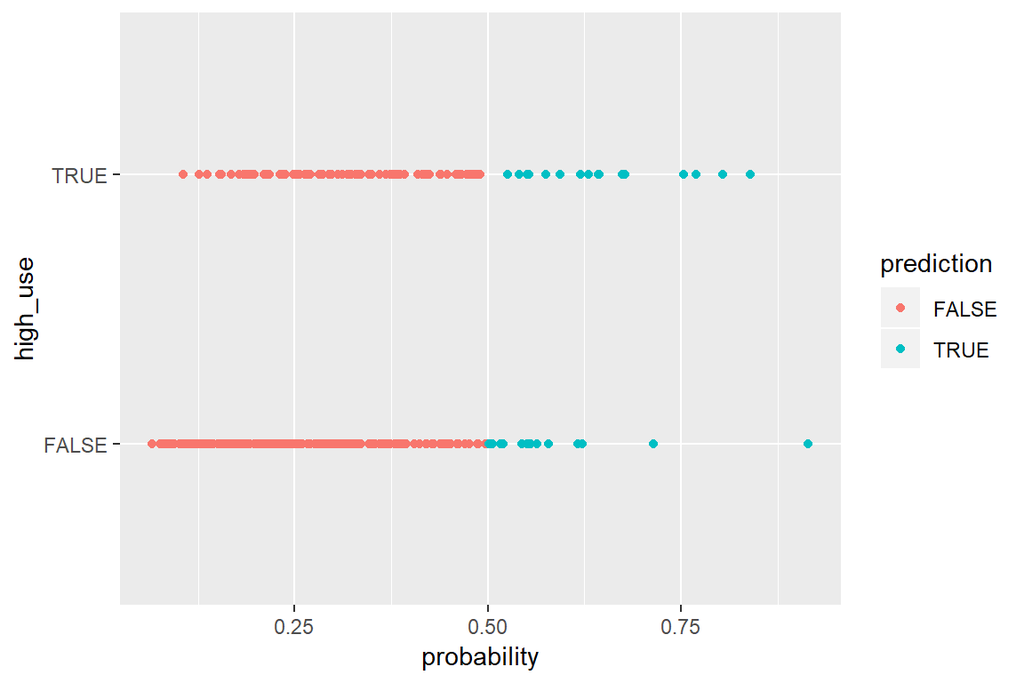

```r
ggplot(alc, aes(x = probability, y = high_use, col = prediction)) + geom_point()
```

We would like to know the actual accuracy of our predictions, so let’s calculate how much we actually predicted wrong:

```r
mean(abs(alc$high_use - alc$probability) > 0.5)
```

```
## [1] 0.2958115
```

So less than third of the values were predicted incorreclty. It does not sound that great. However, it would be interesting to find out how well we would do if we just guessed the values, so let’s try that!

```r
alc$guess <- runif(382, 0, 1)

mean(abs(alc$high_use - alc$guess) > 0.5)
```

```
## [1] 0.4947644
```

So as we can see, our model actually predicted much better than just random guessing! We probably could improve our model by choosing other variables but as long as we can do better than guessing I think we are doing something right.

## Week 4: Clustering and classification

### Data

In this week’s report we are focusing on clustering and classifying data. Clustering is a method for trying to find similar data points and dividing them in different groups. The groups are not known beforehand. In classification we are trying to do the same thing but we are actually knowing the groups. The data we are using for this is the *Boston* data that is part of the `MASS` package in R. The data is about housing values in Boston. Specific description of the data can be found [here](https://stat.ethz.ch/R-manual/R-devel/library/MASS/html/Boston.html). After loading the dataset and running the codes for structure and summary we’ll get this kind of results:

```r
library(MASS)
library(corrplot)
library(ggplot2)

boston <- Boston

dim(boston)
```

```
## [1] 506  14
```

```r
str(boston)
```

```
## 'data.frame':    506 obs. of  14 variables:
##  $ crim   : num  0.00632 0.02731 0.02729 0.03237 0.06905 ...
##  $ zn     : num  18 0 0 0 0 0 12.5 12.5 12.5 12.5 ...
##  $ indus  : num  2.31 7.07 7.07 2.18 2.18 2.18 7.87 7.87 7.87 7.87 ...
##  $ chas   : int  0 0 0 0 0 0 0 0 0 0 ...
##  $ nox    : num  0.538 0.469 0.469 0.458 0.458 0.458 0.524 0.524 0.524 0.524 ...
##  $ rm     : num  6.58 6.42 7.18 7 7.15 ...
##  $ age    : num  65.2 78.9 61.1 45.8 54.2 58.7 66.6 96.1 100 85.9 ...
##  $ dis    : num  4.09 4.97 4.97 6.06 6.06 ...
##  $ rad    : int  1 2 2 3 3 3 5 5 5 5 ...
##  $ tax    : num  296 242 242 222 222 222 311 311 311 311 ...
##  $ ptratio: num  15.3 17.8 17.8 18.7 18.7 18.7 15.2 15.2 15.2 15.2 ...
##  $ black  : num  397 397 393 395 397 ...
##  $ lstat  : num  4.98 9.14 4.03 2.94 5.33 ...
##  $ medv   : num  24 21.6 34.7 33.4 36.2 28.7 22.9 27.1 16.5 18.9 ...
```

```r
summary(boston)
```

```
##       crim                zn             indus            chas
##  Min.   : 0.00632   Min.   :  0.00   Min.   : 0.46   Min.   :0.00000
##  1st Qu.: 0.08204   1st Qu.:  0.00   1st Qu.: 5.19   1st Qu.:0.00000
##  Median : 0.25651   Median :  0.00   Median : 9.69   Median :0.00000
##  Mean   : 3.61352   Mean   : 11.36   Mean   :11.14   Mean   :0.06917
##  3rd Qu.: 3.67708   3rd Qu.: 12.50   3rd Qu.:18.10   3rd Qu.:0.00000
##  Max.   :88.97620   Max.   :100.00   Max.   :27.74   Max.   :1.00000
##       nox               rm             age              dis
##  Min.   :0.3850   Min.   :3.561   Min.   :  2.90   Min.   : 1.130
##  1st Qu.:0.4490   1st Qu.:5.886   1st Qu.: 45.02   1st Qu.: 2.100
##  Median :0.5380   Median :6.208   Median : 77.50   Median : 3.207
##  Mean   :0.5547   Mean   :6.285   Mean   : 68.57   Mean   : 3.795
##  3rd Qu.:0.6240   3rd Qu.:6.623   3rd Qu.: 94.08   3rd Qu.: 5.188
##  Max.   :0.8710   Max.   :8.780   Max.   :100.00   Max.   :12.127
##       rad              tax           ptratio          black
##  Min.   : 1.000   Min.   :187.0   Min.   :12.60   Min.   :  0.32
##  1st Qu.: 4.000   1st Qu.:279.0   1st Qu.:17.40   1st Qu.:375.38
##  Median : 5.000   Median :330.0   Median :19.05   Median :391.44
##  Mean   : 9.549   Mean   :408.2   Mean   :18.46   Mean   :356.67
##  3rd Qu.:24.000   3rd Qu.:666.0   3rd Qu.:20.20   3rd Qu.:396.23
##  Max.   :24.000   Max.   :711.0   Max.   :22.00   Max.   :396.90
##      lstat            medv
##  Min.   : 1.73   Min.   : 5.00
##  1st Qu.: 6.95   1st Qu.:17.02
##  Median :11.36   Median :21.20
##  Mean   :12.65   Mean   :22.53
##  3rd Qu.:16.95   3rd Qu.:25.00
##  Max.   :37.97   Max.   :50.00
```

To have a better understanding about the distributions of the variables and their relationships, we should make some graphs. Here are some histograms and bar charts made from the variables, and also a correlation matrix:

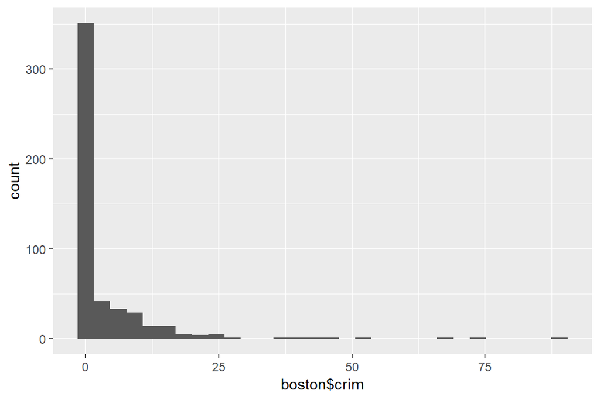

```r
ggplot(data = boston, aes(boston$crim)) + geom_histogram()
```

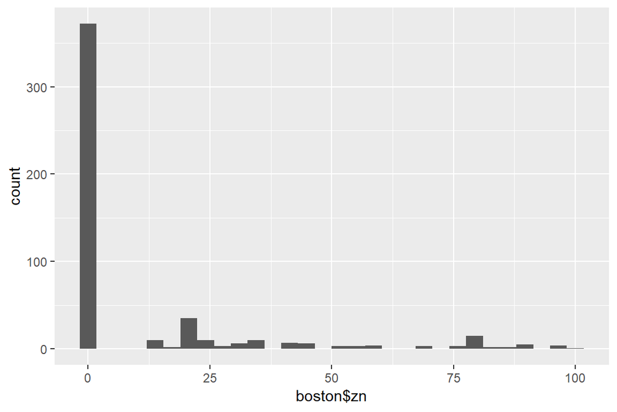

```r
ggplot(data = boston, aes(boston$zn)) + geom_histogram()
```

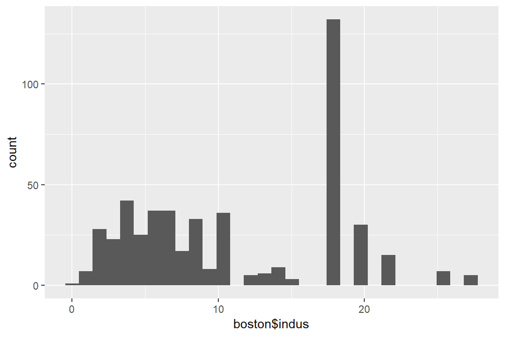

```r
ggplot(data = boston, aes(boston$indus)) + geom_histogram()
```

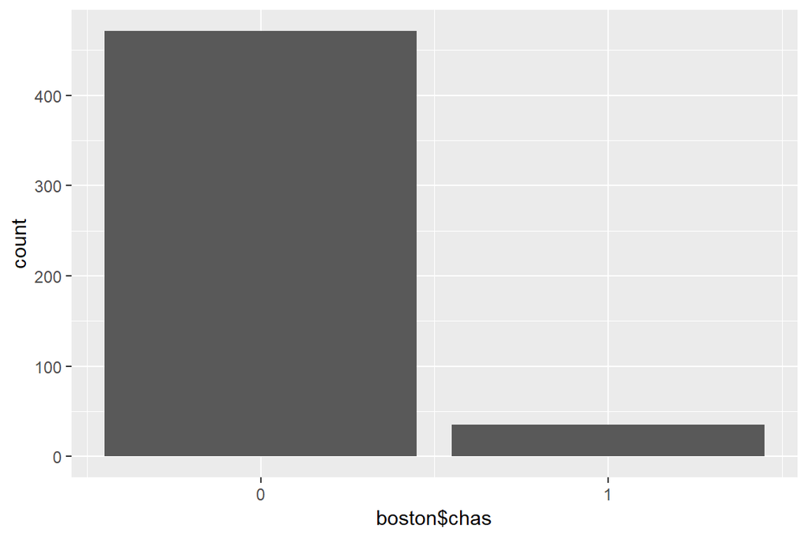

```r
ggplot(data = boston, aes(boston$chas)) + geom_bar() + scale_x_continuous(breaks = 0:1, labels=c("0","1"))
```

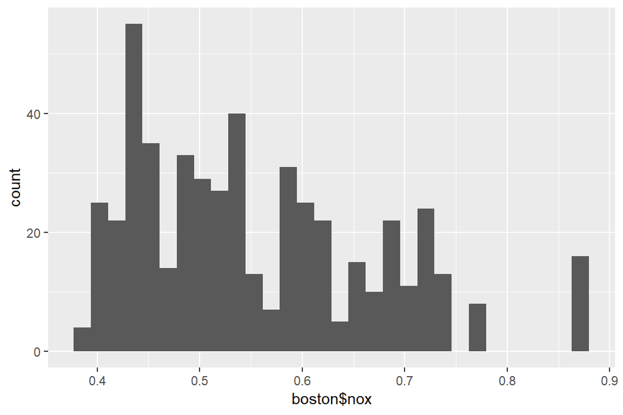

```r
ggplot(data = boston, aes(boston$nox)) + geom_histogram()
```

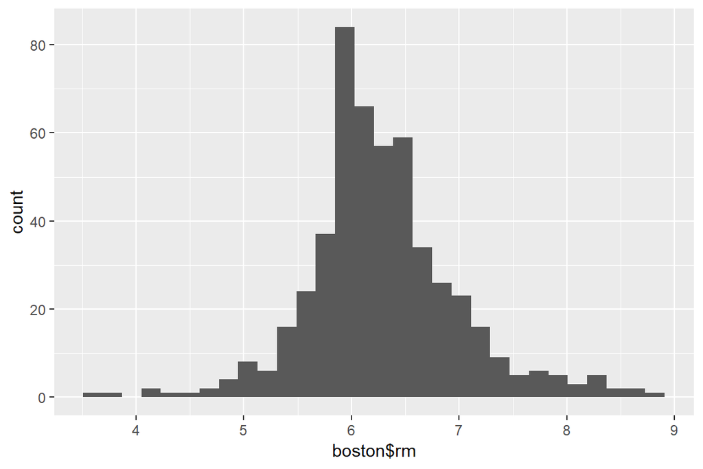

```r
ggplot(data = boston, aes(boston$rm)) + geom_histogram()
```

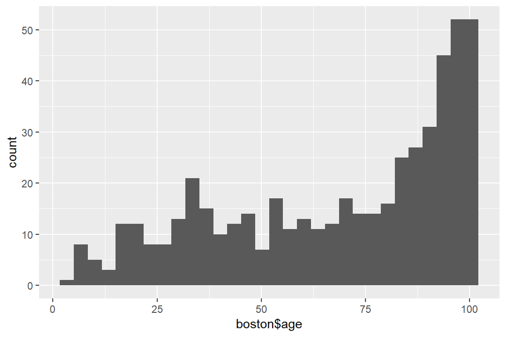

```r
ggplot(data = boston, aes(boston$age)) + geom_histogram()
```

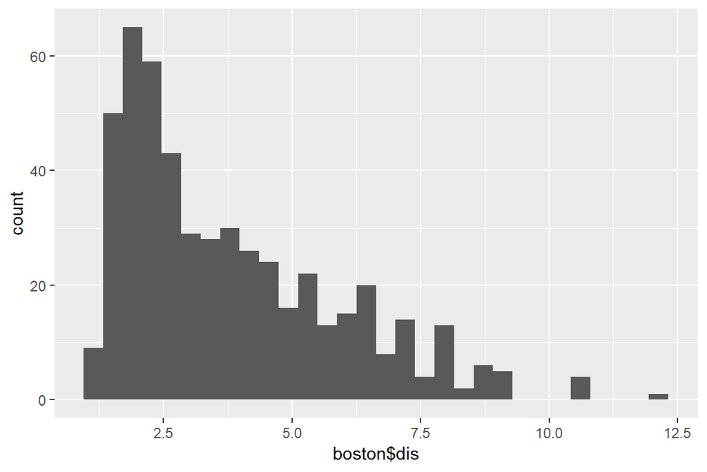

```r
ggplot(data = boston, aes(boston$dis)) + geom_histogram()
```

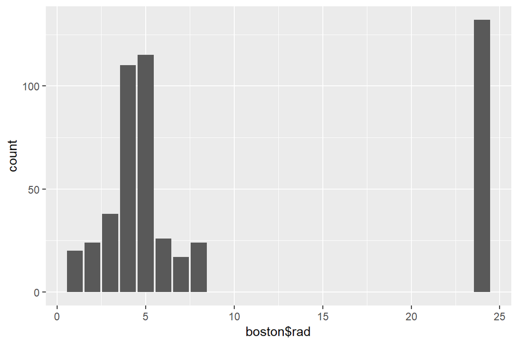

```r
ggplot(data = boston, aes(boston$rad)) + geom_bar()
```

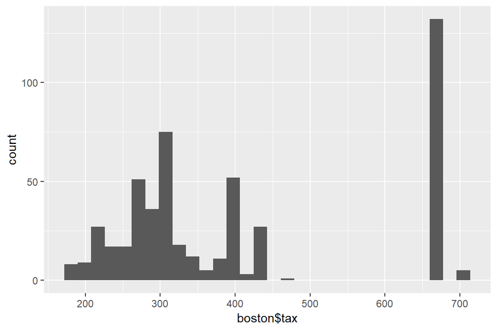

```r
ggplot(data = boston, aes(boston$tax)) + geom_histogram()
```

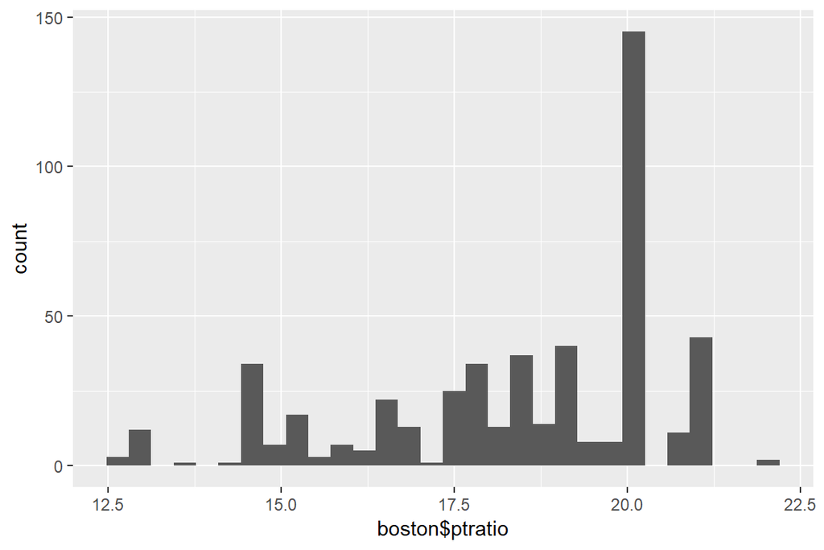

```r
ggplot(data = boston, aes(boston$ptratio)) + geom_histogram()
```

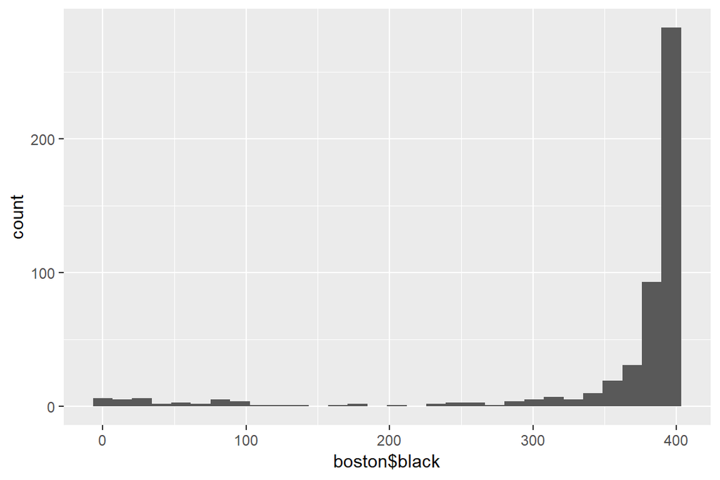

```r
ggplot(data = boston, aes(boston$black)) + geom_histogram()
```

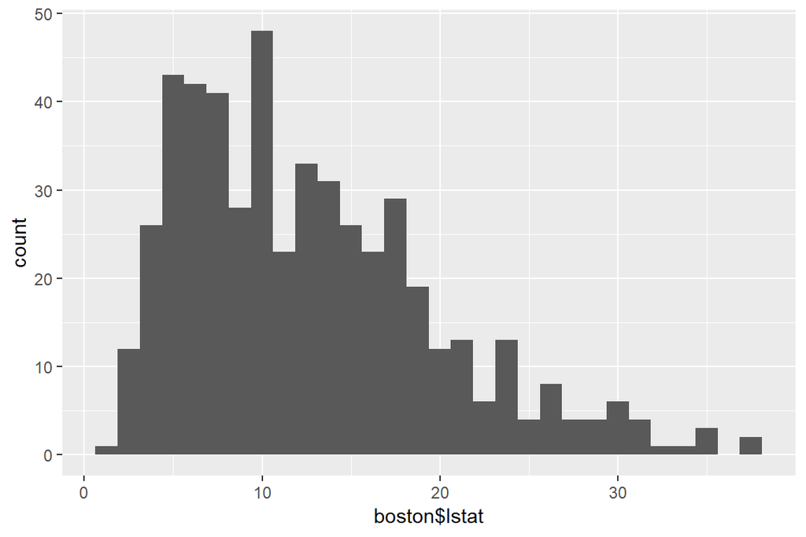

```r
ggplot(data = boston, aes(boston$lstat)) + geom_histogram()
```

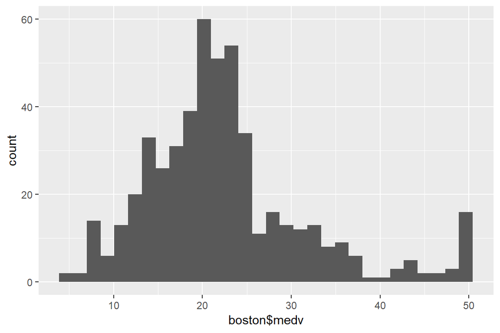

```r
ggplot(data = boston, aes(boston$medv)) + geom_histogram()
```

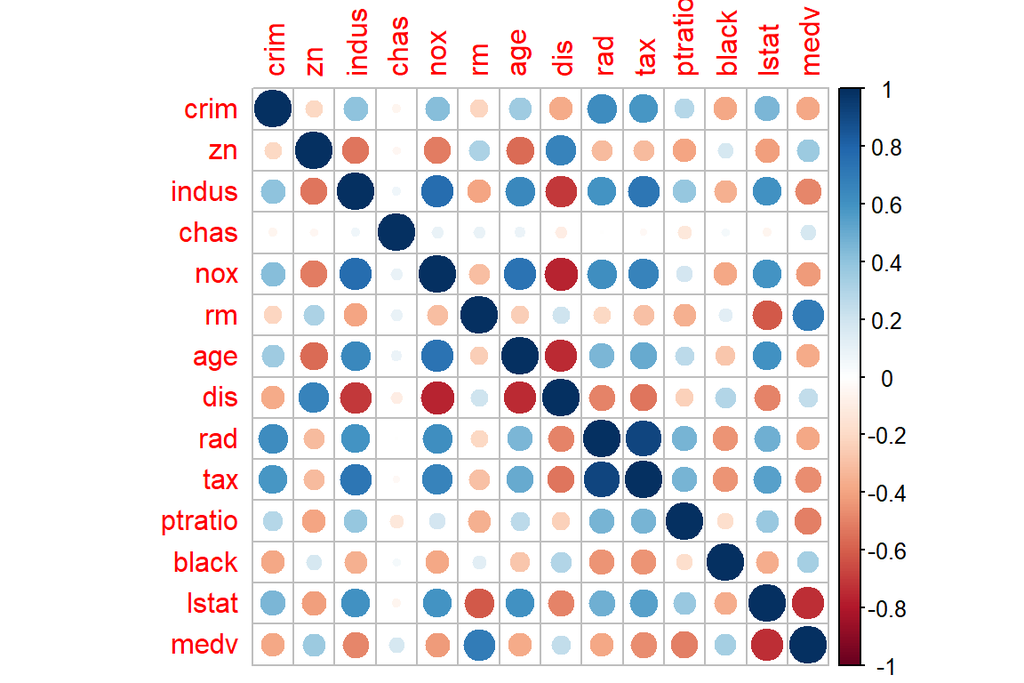

```r
corrplot(cor(boston), method = "circle")
```

As we earlier noticed, the variables have really different distributions. Only one or two of them seem to distribute somehow normally (`rm` and `medv`). Now if we look at the correlation matrix, there are certainly multiple interesting relationships. The blue spots indicate positive correlation and red ones negative. For example variables `tax` and `rad` have correlation approximately 0.8, and variables `nox` and `dis` approximately -0.8. It means that if values of `tax` or `rad` increase, values of the other variable woud increase as well. And if values of `nox` or `dis` increase, values of the other variable would decrease. We do not know the causality between any of these variables - only linear correlation.

Now that we are familiar with the data we can move on to some scaling.

### Scaling and standardization

Because these variables have really different ranges and distributions, it would be a good idea to scale them so that all of them are centered in a same way. The command `scale()` calculates the means and standard deviations of the variables and uses them to standardize them. This is what our data (named as `boston_scaled`) looks like after scaling:

```r
boston_scaled <- as.data.frame(scale(boston))
summary(boston_scaled)
```

```
##       crim                 zn               indus
##  Min.   :-0.419367   Min.   :-0.48724   Min.   :-1.5563
##  1st Qu.:-0.410563   1st Qu.:-0.48724   1st Qu.:-0.8668
##  Median :-0.390280   Median :-0.48724   Median :-0.2109
##  Mean   : 0.000000   Mean   : 0.00000   Mean   : 0.0000
##  3rd Qu.: 0.007389   3rd Qu.: 0.04872   3rd Qu.: 1.0150
##  Max.   : 9.924110   Max.   : 3.80047   Max.   : 2.4202
##       chas              nox                rm               age
##  Min.   :-0.2723   Min.   :-1.4644   Min.   :-3.8764   Min.   :-2.3331
##  1st Qu.:-0.2723   1st Qu.:-0.9121   1st Qu.:-0.5681   1st Qu.:-0.8366
##  Median :-0.2723   Median :-0.1441   Median :-0.1084   Median : 0.3171
##  Mean   : 0.0000   Mean   : 0.0000   Mean   : 0.0000   Mean   : 0.0000
##  3rd Qu.:-0.2723   3rd Qu.: 0.5981   3rd Qu.: 0.4823   3rd Qu.: 0.9059
##  Max.   : 3.6648   Max.   : 2.7296   Max.   : 3.5515   Max.   : 1.1164
##       dis               rad               tax             ptratio
##  Min.   :-1.2658   Min.   :-0.9819   Min.   :-1.3127   Min.   :-2.7047
##  1st Qu.:-0.8049   1st Qu.:-0.6373   1st Qu.:-0.7668   1st Qu.:-0.4876
##  Median :-0.2790   Median :-0.5225   Median :-0.4642   Median : 0.2746
##  Mean   : 0.0000   Mean   : 0.0000   Mean   : 0.0000   Mean   : 0.0000
##  3rd Qu.: 0.6617   3rd Qu.: 1.6596   3rd Qu.: 1.5294   3rd Qu.: 0.8058
##  Max.   : 3.9566   Max.   : 1.6596   Max.   : 1.7964   Max.   : 1.6372
##      black             lstat              medv
##  Min.   :-3.9033   Min.   :-1.5296   Min.   :-1.9063
##  1st Qu.: 0.2049   1st Qu.:-0.7986   1st Qu.:-0.5989
##  Median : 0.3808   Median :-0.1811   Median :-0.1449
##  Mean   : 0.0000   Mean   : 0.0000   Mean   : 0.0000
##  3rd Qu.: 0.4332   3rd Qu.: 0.6024   3rd Qu.: 0.2683
##  Max.   : 0.4406   Max.   : 3.5453   Max.   : 2.9865
```

Now mean of all variables is 0. This way they are much more comparable since they are centered same way.

Next we’ll make a new variable also called `crime` which is actually a categorical variable that is made from the original `crime`. The new variable uses the quantiles from the original variable as its break points. After this, the old `crime` will be dropped and we’ll use the new one.

```r
bins <- quantile(boston_scaled$crim)
bins
```

```
##           0%          25%          50%          75%         100%
## -0.419366929 -0.410563278 -0.390280295  0.007389247  9.924109610
```

```r
crime <- cut(boston_scaled$crim, breaks = bins , label = c("low", "med_low", "med_high", "high"), include.lowest = TRUE)
table(crime)
```

```
## crime
##      low  med_low med_high     high
##      127      126      126      127
```

```r
boston_scaled <- dplyr::select(boston_scaled, -crim)

boston_scaled <- data.frame(boston_scaled, crime)
```

This is all the data manipulation we will need! Now it’s time for train and test sets.

### Test and train data sets

In machine learning it is important that we use different data for training the model and when testing its goodness. If this wasn’t done, the model would probably overfit or not be suitable for other datasets in some other way. That is why we will split our current dataset. Usually the amount of data that is given for test set is around 10-40%, usually 20-30%. We will use 20% so that we have enough data for training:

```r
sample_size <- floor(0.80 * nrow(boston_scaled))
set.seed(42)
train_indices <- sample(seq_len(nrow(boston_scaled)), size = sample_size)

train <- boston_scaled[train_indices, ]
test <- boston_scaled[-train_indices, ]
```

After the splitting we are ready for some modelling.

### LDA

This time we are going to use linear discriminant analysis that is suitable for classification (so we know the groups before fitting the model!) tasks. Our categorical variable, which defines the class, is the one that we created in previous part. It means that it is going to be our target variable while the other variables will be the predictors. Let’s fit the model and see what kind of results we are getting:

```r
lda.fit <- lda(crime ~., data = train)


lda.fit
```

```
## Call:
## lda(crime ~ ., data = train)
##
## Prior probabilities of groups:
##       low   med_low  med_high      high
## 0.2574257 0.2351485 0.2376238 0.2698020
##
## Group means:
##                  zn      indus        chas        nox         rm
## low       0.8493721 -0.8697340 -0.12090214 -0.8619406  0.4323810
## med_low  -0.0476367 -0.3616877 -0.02367011 -0.6349827 -0.1030773
## med_high -0.3871935  0.1739756  0.17879700  0.3432386  0.1244914
## high     -0.4872402  1.0149946 -0.05560795  1.0712213 -0.3889671
##                 age        dis        rad        tax     ptratio
## low      -0.8500445  0.7994565 -0.6892330 -0.7415431 -0.42271224
## med_low  -0.4750741  0.5060898 -0.5345735 -0.5367257 -0.06065883
## med_high  0.4038831 -0.3601235 -0.4207972 -0.3145182 -0.19982809
## high      0.8033749 -0.8519341  1.6596029  1.5294129  0.80577843
##               black       lstat        medv
## low       0.3877799 -0.77386763  0.51551359
## med_low   0.3228171 -0.17438217  0.03340113
## med_high  0.1429415 -0.01151508  0.17946160
## high     -0.8353394  0.89641301 -0.70881495
##
## Coefficients of linear discriminants:
##                 LD1         LD2         LD3
## zn       0.09823274  0.50670671 -1.08729424
## indus    0.03111473 -0.23288590  0.48589410
## chas    -0.10543021 -0.03031872  0.11827513
## nox      0.24893075 -0.99359892 -0.97953460
## rm      -0.08342747 -0.12461232 -0.13456351
## age      0.31441545 -0.35506917 -0.21656507
## dis     -0.12038125 -0.23973804  0.61335376
## rad      3.56444799  1.13916235  0.09948690
## tax      0.20471600 -0.08489325  0.16722950
## ptratio  0.16215783 -0.09228254 -0.21123315
## black   -0.12925677  0.02162516  0.10894040
## lstat    0.12271248 -0.19098632  0.59411810
## medv     0.13413556 -0.42899275  0.01244778
##
## Proportion of trace:
##    LD1    LD2    LD3
## 0.9641 0.0267 0.0092
```

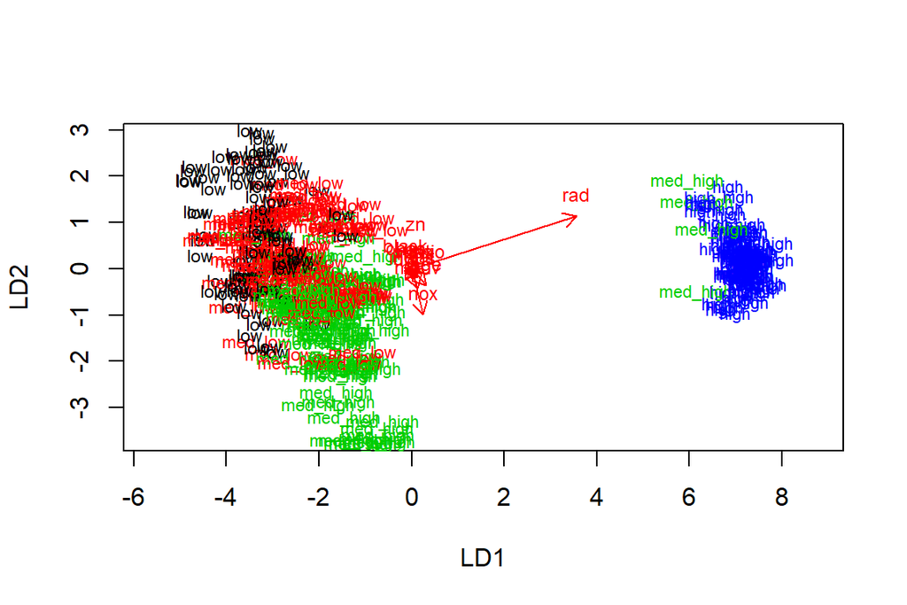

```r
# the function for lda biplot arrows
lda.arrows <- function(x, myscale = 1, arrow_heads = 0.1, color = "red", tex = 0.75, choices = c(1,2)){
  heads <- coef(x)
  arrows(x0 = 0, y0 = 0,
         x1 = myscale * heads[,choices[1]],
         y1 = myscale * heads[,choices[2]], col=color, length = arrow_heads)
  text(myscale * heads[,choices], labels = row.names(heads),
       cex = tex, col=color, pos=3)
}

classes <- as.numeric(train$crime)

plot(lda.fit, col = classes, pch = classes, dimen = 2)
lda.arrows(lda.fit, myscale = 1)
```

From the model summary we can see the prior probabilites for each group. All groups seem to have almost same probability (because we used the quantiles as break points) so there is no dominant group. Then we can see some group means and coefficients for the redictors. LD1, LD2 and LD3 are the linear discriminants and because we have four groups we have three LDs. Proportion of trace tells how much the discriminant explains the variance between groups. The first one has clearly the highest explanation rate.

The plot of the linear discriminants can show us how the groups are scattered and how the predictors impact on the model. The arrow that represents `rad` is significantly longer than others so it has the highest impact, and it is pointing to group *high*. The arrow of variable `nox` is also a bit longer than others. We can see that the group *high* is completely separated from others, though there are few lost *med-high* values.

### Validation

Now that we have trained our model, we need to test it to see how well it actually works. We’ll use the model to the test data and check which group it chooses for each data point. Then we’ll compare the results for the real values to see how good the model is for predicting the target variable `crime`. If the model does not predict well, it needs to be tuned and then tested again.

```r
correct_classes <- test$crime
test <- dplyr::select(test, -crime)

lda.pred <- predict(lda.fit, newdata = test)

# cross tabulate the results
table(correct = correct_classes, predicted =  lda.pred$class)
```

```
##           predicted
## correct    low med_low med_high high
##   low       18       4        1    0
##   med_low    5      12       14    0
##   med_high   1       5       22    2
##   high       0       0        1   17
```